# 低波動搭配動能_量化投資組合建構

Neil LEE

我的Github : https://github.com/migue1neil/low-volatility_momentum_portfolio

# 簡介

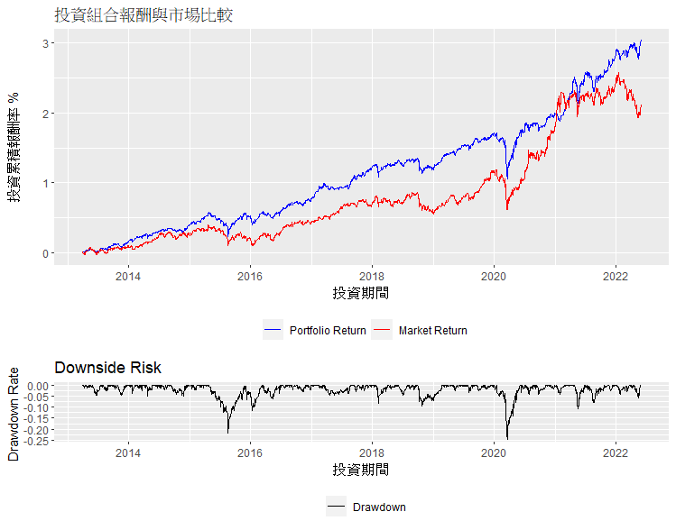

在上圖中，我們可以看到，用兩個指標所設計出來的投資組合與市場報酬的比較。從圖中可以得知在大多數情況下，此投組績效略優於大盤，此外，本次僅使用股價波動與趨勢當作買賣依據使用，並未使用基本面等財報資訊，未來可以再加入品質因子來看看近幾年台股投組的績效如何，並加以優化自己的策略。

# 程式功能:

可以根據自己想的條件設定每月換股的股票

# 資料來源與計算方式

首先載入相關套件

```r
# package_list = c("data.table","dplyr","plyr","readr","ggplot2","lubridate","tseries","magrittr","foreach","cowplot")
library(data.table)
library(dplyr)
library(plyr)
library(readr) #讀取檔案必備
library(ggplot2) # 畫圖使用
library(lubridate) #轉換日期使用
library(tseries) #會用到最大回落
library(magrittr) # %>% 水管工人
library(TTR) #量化套件，結合dplyr使用可以快速分組做計算
library(cowplot)
```

這邊是上篇文章中計算電信三雄投組所設計出來的功能，可以計算期初到期末的報酬率，本篇程式的目的著重在篩選時間，並且分批投入此函數，計算出每期報酬後再用累成方式算出期末報酬。

```r
source("portfolio_function.R" , encoding = "utf-8")
source("caculate_index_function.R" , encoding = "utf-8")
```

載入整理好的股價資料

```r
table_data = fread("C:/Users/Neil/Documents/git-repos/backtest_in_R/stock_data/tidy_stock_price_data20000101_20220613.txt", encoding = "unknown" , header = T,sep = ",")
table_data = table_data[年月日 > 20100101,]
head(table_data)
```

```
##    證券代碼   公司名稱   年月日 調整開盤價 調整最高價 調整最低價 調整收盤價
## 1:       50 元大台灣50 20100104    38.1333    38.2684    37.8631    38.1670
## 2:       50 元大台灣50 20100105    38.3697    38.4373    37.9306    38.1670
## 3:       50 元大台灣50 20100106    38.1670    39.0115    38.1670    38.8763
## 4:       50 元大台灣50 20100107    38.9101    39.2817    38.7075    38.7750
## 5:       50 元大台灣50 20100108    38.7075    39.0115    38.5386    39.0115
## 6:       50 元大台灣50 20100111    38.5724    39.2141    38.5724    39.1128
##    成交張數 市場別 TSE產業別 隔日開盤價 後日開盤價 open_price_daily_change
## 1:    20083    TSE         0    38.3697    38.1670            -0.005282814
## 2:    16453    TSE         0    38.1670    38.9101             0.019469699
## 3:    19012    TSE         0    38.9101    38.7075            -0.005206874
## 4:    14110    TSE         0    38.7075    38.5724            -0.003490280
## 5:    11342    TSE         0    38.5724    38.8763             0.007878690
## 6:    11581    TSE         0    38.8763    38.5386            -0.008686526
##    股價年標準差 Price_MA_20 Price_MA_60 Price_MA_120 Price_MA_252
## 1:     5.311725    36.75858    36.17195     34.79396     30.21500
## 2:     5.313748    36.84471    36.21584     34.84756     30.27648
## 3:     5.319328    36.97474    36.27044     34.90359     30.34084
## 4:     5.325179    37.09465    36.31618     34.95933     30.40360
## 5:     5.322781    37.25509    36.36254     35.01659     30.47310
## 6:     5.319166    37.39188    36.41059     35.07454     30.54354
##    CV股價離散程度
## 1:      0.1757976
## 2:      0.1755074
## 3:      0.1753191
## 4:      0.1751496
## 5:      0.1746715
## 6:      0.1741503
```

在這邊我們要設定一些參數，方便在後面設計成function的時候採用

```r
start_day = 20130101         #投資開始日期
end_day = 20220601           #投資結束日期
discount = 0                 #券商手續費折舊
trade_frequency = "season"   #投資頻率
A = 100                      #起時投入的金額
global_market_index = 0050   #要比較的標的
```

# 時間參數設計

做完初步的設定後，我們需要使用R來設計量化投資的回測系統，首先，我們要先設定一個時間，知道要在哪個時間點買賣股票，同時避開假日。 同時我們了解到資訊是有時間價值的，訊息公告越久會越不值錢。 因此，我們希望可以設計一個功能，能在月報截止日的第一天買入，或者可以在季報截止日的第一天買入，又或者可以在年報截止日的第一天買入。

```r
trade_time_func = function( table_data , start_day = 20130101 , end_day = 20220101 , trade_frequency = "season" ){
  #年報截止日
  year_trade = c(0331)
  #季報截止日
  season_trade = c(0331,0515,0814,1114)
  #月營收截止日
  monthly_trade = seq(from = 110 , to = 1210 , by = 100) #每個月10號
  #設計一個要月交易還是季交易的判斷式
  #trade_frequency
  check_day = 0
  trade_frequency = trade_frequency %>% tolower()
  if(trade_frequency == "month"){
    check_day = 1
    trade_frequency = monthly_trade
  }else if (trade_frequency == "season"){
    trade_frequency = season_trade
  }else if (trade_frequency == "year"){
    trade_frequency = year_trade
  }else{
    print("設定頻率可能有錯，請檢查 ~")
    break
  }

  # 找出最後end_day前的最後一筆交易日
  end_day = subset(table_data$年月日,table_data$年月日 <= end_day) %>% max() %>% as.numeric()
  year = c( year(ymd(start_day)) : year(ymd(end_day)) )  #取出年，用Vector c(起始年:結束年)

  #檢查交易日，生成一個要交易的日期，會根據上面上定的條件，產生一筆交易日期
  trade_day = data.frame(年月日 = NA)
  for (i in year){
    for (j in trade_frequency){
      dd = subset(table_data$年月日, table_data$年月日 >= (i*10000+j))[1]
    trade_day = rbind( trade_day,dd )
    }
  }
  trade_day = na.omit(trade_day)
  rownames(trade_day) = NULL

  # 生產一個買入日期和賣出日期的df，假設不是持有N天，而是每期都把上期的東西賣掉，重新買入新的。
  trade_pair = data.frame(買 = NA ,賣 = NA)
  for (i in c(1:length(trade_day$年月日))){
  tmp = data.frame(買 = trade_day$年月日[i])
  tmp$賣 = trade_day$年月日[i+1] #幫tmp生成一個賣
  trade_pair = rbind(trade_pair,tmp)
  }
  # 如果時間提前結束的話最後一筆交易日是空的，所以要拿截止時間點當賣出的資料補齊
  trade_pair$賣[length(trade_pair$賣)] = end_day #將最後一筆資料放到dataframe裡面，
  trade_pair = trade_pair %>% na.omit()
  rownames(trade_pair) = NULL # reset index

  if(check_day == 1){
    if ( length(which(trade_pair$買 > trade_pair$賣)) > 0 ){  #檢查如果最後一天小於買入日期的話要修正
      trade_pair = trade_pair[-nrow(trade_pair),]
      trade_pair$賣[length(trade_pair$賣)] = end_day
    }
  }
  return(trade_pair)
}
```

設計完上面的函數之後，我們可以得到買入日期和賣出日期

```r
trade_pair = trade_time_func(table_data , start_day = start_day , end_day = end_day , trade_frequency = trade_frequency )
trade_day = trade_pair$買
head(trade_pair)
```

```
##         買       賣
## 1 20130401 20130515
## 2 20130515 20130814
## 3 20130814 20131114
## 4 20131114 20140331
## 5 20140331 20140515
## 6 20140515 20140814
```

# 篩選投資標的

有了這些日期之後，就要設計一個function，根據上面篩選好的日期篩選，把每次要交易的”那一天”股票篩選出來，最後在合併成一個list格式，形成一個每期要買入股票的表格

```r
standby_stock_list = data.table()
  for(i in   1:length(trade_day)){
    buy_day= trade_day[i] # buy_day會等於那一天的資料
    tmp_a = table_data[table_data$年月日 == buy_day,]  # 目的:生產出要買進股票那一天的資料
    tmp_a = tmp_a %>% na.omit() # 移除空值

    # 篩選開始
     tmp_a = tmp_a %>% filter(TSE產業別 > 0) # 剔除非正常的股票，例如ETF和債券
     tmp_a = tmp_a %>% filter(證券代碼 > 1000 & 證券代碼< 10000) # 同上
     tmp_a = tmp_a %>% filter(tmp_a$Price_MA_20 > 10) #排除雞蛋水餃股
     tmp_a = tmp_a[tmp_a$成交張數 > 300 ,] #流動性，排除流動性不佳的股票，避免買不到
     tmp_a = tmp_a[tmp_a$調整收盤價 > tmp_a$Price_MA_60, ] #季線上 動能
     cardinal = order(tmp_a$CV股價離散程度, decreasing = F) #依照CV做排序，由小排到大
    # 篩選結束

    # 收集篩選出來的股票資料
    tmp_a = tmp_a[cardinal,]
    rownames(tmp_a) = NULL
    tmp_a = tmp_a[1:30,] # 取前30隻最大的股票
    tmp_b = data.table(stock_list = tmp_a$證券代碼) #收集這30隻的證券代碼
    standby_stock_list = cbind(standby_stock_list,tmp_b) #匯出
  }
head(standby_stock_list)
```

```
##    stock_list stock_list stock_list stock_list stock_list stock_list stock_list
## 1:       1513       1513       1102       3036       5533       2412       4720
## 2:       1733       1733       8927       2421       2412       1708       2412
## 3:       2480       8926       3036       9905       1808       2101       2002
## 4:       1732       2460       6204       1731       6115       2104       5533
## 5:       8422       2606       2637       1540       5511       8072       1419
## 6:       3026       2412       8926       2511       8926       1731       3028
##    stock_list stock_list stock_list stock_list stock_list stock_list stock_list
## 1:       2412       9925       2908       2908       2489       3045       3045
## 2:       6210       3028       9925       5213       1717       4904       4904
## 3:       2603       2412       2031       2412       2330       2637       2892
## 4:       2850       2608       1316       5388       1203       2801       2912
## 5:       4417       5508       1603       2538       2850       1717       2204
## 6:       2908       1417       9933       1216       2464       2912       1216
##    stock_list stock_list stock_list stock_list stock_list stock_list stock_list
```

[output cut: 27 more lines]

# 分批投入回測

接著把上面的表格放到(portfolio_func)回測裡面，分批算出每期的報酬指數。此外，若選出的股票期末沒有股價資料，有可能是被併購或是下市，直接以零(-100%)做計算。

```r
log_trade_list = data.table()
log_portfolio_stock_trade = data.table()
each_portfolio_return_rate = data.table()
  for(i in  1:length(standby_stock_list)  ){
    aa = standby_stock_list[,i , with = FALSE] %>% na.omit()
    aa = aa$stock_list %>% as.vector()
    bb = trade_pair$買[i]
    cc = trade_pair$賣[i]
    dd = portfolio_function(table_data, start_day = bb , end_day = cc , stock_list = aa , A = A ,discount = discount, global_market_index = global_market_index)
    log_trade_list = rbind(log_trade_list,dd[[1]])
    log_portfolio_stock_trade = rbind(log_portfolio_stock_trade,dd[[2]])
    each_portfolio_return_rate = rbind(each_portfolio_return_rate, dd[[3]])
  }
```

[output not shown]

[output cut: 41 more lines]

[output not shown]

計算完成後可以得到三張表格，分別是每天交易的漲跌幅紀錄

```r
head(log_trade_list)
```

```
##      開始日期   結束日期    期間總報酬 投組最大回落 投組回落開始時間
## 1: 2013-04-01 2013-05-15  0.0269105853       0.0163       2013-04-02
## 2: 2013-05-15 2013-08-14 -0.0004643912       0.0488       2013-05-17
## 3: 2013-08-14 2013-11-14  0.0432299900       0.0422       2013-10-30
## 4: 2013-11-14 2014-03-31  0.1419195789       0.0403       2014-01-17
## 5: 2014-03-31 2014-05-15 -0.0072712718       0.0487       2014-04-16
## 6: 2014-05-15 2014-08-14  0.0594680745       0.0235       2014-07-22
##    投組回落結束時間 投組回落持續天數 勝率 投資股票數量 市場期間總報酬
## 1:       2013-04-10                8 0.70           30     0.06187625
## 2:       2013-06-19               33 0.53           30    -0.06387226
## 3:       2013-11-12               13 0.58           30     0.05120482
## 4:       2014-01-24                7 0.73           30     0.06972112
## 5:       2014-04-24                8 0.47           30     0.01387512
## 6:       2014-08-06               15 0.77           30     0.08474576
##    市場最大回落 市場回落開始時間 市場回落結束時間 市場回落持續天數 市場勝率
## 1:       0.0289       2013-04-01       2013-04-12               11        1
## 2:       0.0917       2013-05-20       2013-06-21               32        0
## 3:       0.0342       2013-10-30       2013-11-12               13        1
## 4:       0.0532       2013-12-27       2014-01-27               31        1
## 5:       0.0253       2014-04-21       2014-04-24                3        1
## 6:       0.0528       2014-07-14       2014-08-04               21        1
##    市場標的數
## 1:          1
## 2:          1
## 3:          1
## 4:          1
## 5:          1
## 6:          1
```

和每檔股票進出場賺到的報酬

```r
head(log_portfolio_stock_trade)
```

```
##    證券代碼 公司名稱   買入時間 買入開盤價   賣出時間 賣出價格 單筆報酬
## 1:     1231   聯華食 2013-04-01    17.3425 2013-05-15  18.9878   0.0949
## 2:     1325     恒大 2013-04-01    14.2738 2013-05-15  15.1898   0.0642
## 3:     1513   中興電 2013-04-01    11.2015 2013-05-15  11.6796   0.0427
## 4:     1715     萬洲 2013-04-01    10.7152 2013-05-15  11.5308   0.0761
## 5:     1730   花仙子 2013-04-01    11.2567 2013-05-15  11.4364   0.0160
## 6:     1732     毛寶 2013-04-01    14.6339 2013-05-15  13.8973  -0.0503
```

以及投資組合與市場標的的報酬指數比較

```r
head(each_portfolio_return_rate)
```

```
##        年月日 分配後的漲跌幅   市場漲跌幅
## 1: 2013-04-01   0.0057552826  0.001819284
## 2: 2013-04-02   0.0052531711 -0.011796668
## 3: 2013-04-03  -0.0023259432 -0.008264603
## 4: 2013-04-08  -0.0096138998 -0.004629981
## 5: 2013-04-09  -0.0009248123  0.003720722
## 6: 2013-04-10  -0.0019188766  0.008341204
```

# 投組報酬計算

其實這樣就差不多大功告成了，但我們需要近一步計算整個投組的風險報酬指標以及畫圖來做比較

```r
# 把每隻股票日報酬平均之後合併的df，這樣這張df就會有每天分配過後的漲跌幅，用他算報酬。
  each_portfolio_return_rate$投組累積報酬 = (cumprod( each_portfolio_return_rate$分配後的漲跌幅+1 ) -1) %>% round(digits = 4)
  each_portfolio_return_rate$分配後的漲跌幅 = each_portfolio_return_rate$分配後的漲跌幅 %>% round(digits = 4)
  each_portfolio_return_rate$市場累積報酬 = (cumprod( each_portfolio_return_rate$市場漲跌幅+1 ) -1) %>% round(digits = 4)
  each_portfolio_return_rate$市場漲跌幅 = each_portfolio_return_rate$市場漲跌幅 %>% round(digits = 4)

  # 畫DD線
  each_portfolio_return_rate$dd =  ((1+each_portfolio_return_rate$投組累積報酬)/cummax(1+each_portfolio_return_rate$投組累積報酬))-1
  #min(each_portfolio_return_rate$dd)
  #plot(each_portfolio_return_rate$dd)

  # 總報酬
  pf_total_return = each_portfolio_return_rate$投組累積報酬[length(each_portfolio_return_rate$投組累積報酬)]
  market_total_return = each_portfolio_return_rate$市場累積報酬[length(each_portfolio_return_rate$市場累積報酬)]

  # 年化報酬
  year = length(each_portfolio_return_rate$投組累積報酬) / 252
  pf_annual_return = ( (1+pf_total_return)^(1/year) -1 ) %>% round(digits = 3)
  market_annual_return = ( (1+market_total_return)^(1/year) -1 ) %>% round(digits = 3)
  return_df = data.table(投組總報酬 = pf_total_return , 投組年化報酬 = pf_annual_return ,
                              市場總報酬 = market_total_return , 市場年化報酬 = market_annual_return)

  # 最大回落
  each_portfolio_return_rate$投組累積報酬指數 = each_portfolio_return_rate$投組累積報酬+1
  mdd = maxdrawdown(each_portfolio_return_rate$投組累積報酬指數)
  mdd_ratio = (each_portfolio_return_rate$投組累積報酬指數[mdd$to] - each_portfolio_return_rate$投組累積報酬指數[mdd$from]) / each_portfolio_return_rate$投組累積報酬指數[mdd$from]
  mdd_ratio = round(mdd_ratio,digits = 3)
  mdd_start_day = each_portfolio_return_rate$年月日[mdd$from] #最大回落高點日期
  mdd_end_day = each_portfolio_return_rate$年月日[mdd$to] #最大回落低點日期
  mdd_during_period = (mdd_end_day - mdd_start_day) %>% as.numeric()   #回落時間
  each_portfolio_return_rate$市場累積報酬指數 = each_portfolio_return_rate$市場累積報酬+1
  mdd = maxdrawdown(each_portfolio_return_rate$市場累積報酬指數)
  market_mdd_ratio = (each_portfolio_return_rate$市場累積報酬指數[mdd$to] - each_portfolio_return_rate$市場累積報酬指數[mdd$from]) / each_portfolio_return_rate$市場累積報酬指數[mdd$from] %>%   round(digits = 3)
  market_mdd_ratio = round(market_mdd_ratio,digits = 3)
  mdd_df = data.table(投組最大回落 = mdd_ratio , 回落開始日期 =  mdd_start_day ,
                            回落結束日期 = mdd_end_day , 回落持續天數 = mdd_during_period , 市場最大回落 = market_mdd_ratio)

  # 勝率
  winning_percentage = data.table(平均勝率 = mean(log_trade_list$勝率)) %>% round(digits = 2)

  # 把指標打包起來
  trade_period = data.table(投資開始日期 = start_day , 投資結束日期 = end_day)
  trading_ndays = data.table(交易次數 = unique(log_portfolio_stock_trade$買入時間) %>% length() )
  n_stock = data.table(平均投資檔數 = mean(log_trade_list$投資股票數量))
  log_correct_portfolio_final_report = data.table( trade_period, return_df , mdd_df ,
                                            winning_percentage , trading_ndays , n_stock )

  # 統計股票出現次數
  stock_appear_count_list = log_portfolio_stock_trade$證券代碼
  stock_appear_count_list = table(stock_appear_count_list) %>% as.data.table()
  colnames(stock_appear_count_list) = c("證券代碼","出現次數")
  stock_appear_count_list$證券代碼 = stock_appear_count_list$證券代碼 %>% as.numeric()
  log_portfolio_stock_trade = merge(log_portfolio_stock_trade, stock_appear_count_list , by = "證券代碼")

  # 把df打包成list，方便之後設計成函數 return
  log_list_package = list( log_correct_portfolio_final_report , log_trade_list , log_portfolio_stock_trade )
```

算完之後，我們大致上可以得到(1)投資總表，查看整個投資期間的報酬與風險變化如何。從圖表中我們可以觀察到，使用低波動方式的投組，每年的年化報酬有17%，最大跌幅有約25%，相較於市場，年化報酬13%，最大回落18%，可犧牲了波動性換得更大的報酬

```r
log_final_report = log_list_package[[1]]
log_final_report
```

```
##    投資開始日期 投資結束日期 投組總報酬 投組年化報酬 市場總報酬 市場年化報酬
## 1:     20130101     20220601      3.047         0.17     2.0911        0.135
##    投組最大回落 回落開始日期 回落結束日期 回落持續天數 市場最大回落 平均勝率
## 1:       -0.246   2020-01-16   2020-03-18           62        -0.18     0.58
##    交易次數 平均投資檔數
## 1:       38           30
```

(2)投資日誌，每期的投資狀況，方便日後檢查的時候快速查找哪裡有異常報酬或異常波動。

```r
log_trade_list = log_list_package[[2]]
head(log_trade_list)
```

```
##      開始日期   結束日期    期間總報酬 投組最大回落 投組回落開始時間
## 1: 2013-04-01 2013-05-15  0.0269105853       0.0163       2013-04-02
## 2: 2013-05-15 2013-08-14 -0.0004643912       0.0488       2013-05-17
## 3: 2013-08-14 2013-11-14  0.0432299900       0.0422       2013-10-30
## 4: 2013-11-14 2014-03-31  0.1419195789       0.0403       2014-01-17
## 5: 2014-03-31 2014-05-15 -0.0072712718       0.0487       2014-04-16
## 6: 2014-05-15 2014-08-14  0.0594680745       0.0235       2014-07-22
##    投組回落結束時間 投組回落持續天數 勝率 投資股票數量 市場期間總報酬
## 1:       2013-04-10                8 0.70           30     0.06187625
## 2:       2013-06-19               33 0.53           30    -0.06387226
## 3:       2013-11-12               13 0.58           30     0.05120482
## 4:       2014-01-24                7 0.73           30     0.06972112
## 5:       2014-04-24                8 0.47           30     0.01387512
## 6:       2014-08-06               15 0.77           30     0.08474576
##    市場最大回落 市場回落開始時間 市場回落結束時間 市場回落持續天數 市場勝率
## 1:       0.0289       2013-04-01       2013-04-12               11        1
## 2:       0.0917       2013-05-20       2013-06-21               32        0
## 3:       0.0342       2013-10-30       2013-11-12               13        1
## 4:       0.0532       2013-12-27       2014-01-27               31        1
## 5:       0.0253       2014-04-21       2014-04-24                3        1
## 6:       0.0528       2014-07-14       2014-08-04               21        1
##    市場標的數
## 1:          1
## 2:          1
## 3:          1
## 4:          1
## 5:          1
## 6:          1
```

(3)個股報酬統計，可以看每檔股票的買入和賣出時間，這段期間持有多少報酬和總共在投資期間中出現幾次。

```r
log_portfolio_stock_trade = log_list_package[[3]]
head(log_portfolio_stock_trade)
```

```
##    證券代碼 公司名稱   買入時間 買入開盤價   賣出時間 賣出價格 單筆報酬
## 1:     1101     台泥 2013-08-14    20.2607 2013-11-14  21.7829   0.0751
## 2:     1101     台泥 2015-03-31    24.3051 2015-05-15  23.2556  -0.0432
## 3:     1101     台泥 2017-08-14    22.0493 2017-11-14  21.6978  -0.0159
## 4:     1101     台泥 2020-08-14    40.3977 2020-11-16  39.7906  -0.0150
## 5:     1101     台泥 2020-11-16    39.7906 2021-03-31  43.7603   0.0998
## 6:     1101     台泥 2021-05-17    45.0213 2021-08-16  47.9500   0.0651
##    出現次數
## 1:        7
## 2:        7
## 3:        7
## 4:        7
## 5:        7
## 6:        7
```

# 圖表製作

最後來畫張圖看一下，投資組合和市場的差異

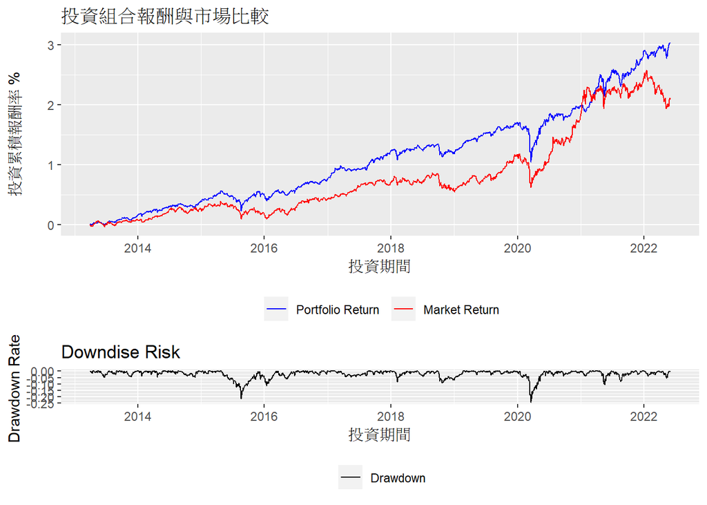

```r
  return_index_image = ggplot(each_portfolio_return_rate , aes(x = 年月日)) +
    geom_line(aes(y = 投組累積報酬, color = "Portfolio Return")) +
    geom_line(aes(y = 市場累積報酬, color = "Market Return" )) +
    ggtitle("投資組合報酬與市場比較") +
    xlab("投資期間") +
    ylab("投資累積報酬率 %" ) +
    scale_color_manual("", values = c("Portfolio Return" = "blue" , "Market Return" = "red" )) +
    theme(
      legend.position = "bottom"
    )
  drawdown_image = ggplot(each_portfolio_return_rate , aes(x = 年月日)) +
     geom_line(aes(y = dd , color = "Drawdown"  )   ) +
     ggtitle("Downdise Risk") +
     xlab("投資期間") +
     ylab("Drawdown Rate ")+
     scale_color_manual("", values = c("Drawdown" = "black")) +
     theme(
        legend.position = "bottom"
     )
   combine_image = plot_grid( return_index_image, drawdown_image ,nrow = 2 , align = "v" , rel_heights = c(2,1))
combine_image
```

將上述功能打包成函數之後可以快速執行回測，雖然如果要改條件還是要點開來改QAQ，但是回測不求快，應該定期檢驗績效就可以了

[output not shown]

[output cut: 42 more lines]

[output not shown]

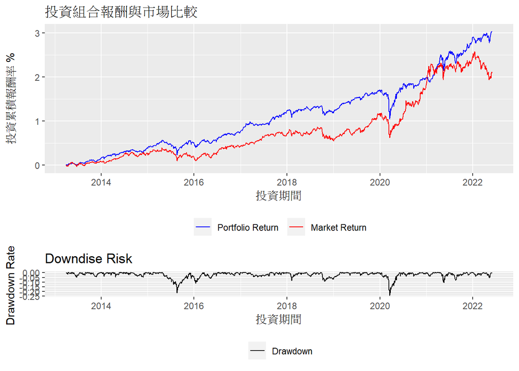

```
## Time difference of 2.560096 mins
```

```r
quant_func = function(table_data, start_day , end_day , A = 100 , global_market_index = 0050 , discount = 0 , trade_frequency = "season" ){
  exe_time = print(Sys.time())
  # 交易時間篩選
  trade_time_func = function( table_data , start_day = 20130101 , end_day = 20220101 , trade_frequency = "season" ){
  #指交易一次 : 開發中，比較不重要
  once_trade = c()
  #年報截止日
  year_trade = c(0331)
  #季報截止日
  season_trade = c(0331,0515,0814,1114)
  #月營收截止日
  monthly_trade = seq(from = 110 , to = 1210 , by = 100) #每個月10號
  #設計一個要月交易還是季交易的判斷式
  #trade_frequency
  check_day = 0
  trade_frequency = trade_frequency %>% tolower()
  if(trade_frequency == "month"){
    check_day = 1
    trade_frequency = monthly_trade
  }else if (trade_frequency == "season"){
    trade_frequency = season_trade
  }else if (trade_frequency == "year"){
    trade_frequency = year_trade
  }else{
    print("設定頻率可能有錯，請檢查 ~")
    break
  }
  # 找出指定日期的第一筆時間
  # 筆記 subset 是vector的篩選函數

  # 找出最後end_day前的最後一筆交易日
  end_day = subset(table_data$年月日,table_data$年月日 <= end_day) %>% max() %>% as.numeric()
  year = c( year(ymd(start_day)) : year(ymd(end_day)) )  #取出年，用Vector c(起始年:結束年)

  #檢查交易日，生成一個要交易的日期，會根據上面上定的條件，產生一筆交易日期
  trade_day = data.frame(年月日 = NA)
  for (i in year){
    for (j in trade_frequency){
      dd = subset(table_data$年月日, table_data$年月日 >= (i*10000+j))[1]
    trade_day = rbind( trade_day,dd )
    }
  }
  trade_day = na.omit(trade_day)
  rownames(trade_day) = NULL

  # 生產一個買入日期和賣出日期的df，假設不是持有N天，而是每期都把上期的東西賣掉，重新買入新的。
  trade_pair = data.frame(買 = NA ,賣 = NA)
  for (i in c(1:length(trade_day$年月日))){
  # cat("***************","\n")
  # cat("買",trade_day$年月日[i],"\n")
  # cat("賣",trade_day$年月日[i+1],"\n")
  # cat("***************","\n")
  tmp = data.frame(買 = trade_day$年月日[i])
  tmp$賣 = trade_day$年月日[i+1] #幫tmp生成一個賣
  trade_pair = rbind(trade_pair,tmp)
  }
  # 如果時間提前結束的話最後一筆交易日是空的，所以要拿截止時間點當賣出的資料補齊
  trade_pair$賣[length(trade_pair$賣)] = end_day # 將最後一筆資料放到df，
  trade_pair = trade_pair %>% na.omit()
  rownames(trade_pair) = NULL # reset index

  if(check_day == 1){
    if ( length(which(trade_pair$買 > trade_pair$賣)) > 0 ){  #檢查如果最後一天小於買入日期的話要修正
      trade_pair = trade_pair[-nrow(trade_pair),]
      trade_pair$賣[length(trade_pair$賣)] = end_day
    }
  }
  return(trade_pair)
}
  trade_pair = trade_time_func(table_data , start_day = start_day , end_day = end_day , trade_frequency = trade_frequency )
  trade_day = trade_pair$買

  # 篩出stock list，設計一個for迴圈，把每次交易日要篩選的股票篩選出來，在合併，形成一籃子要交易的股票
  # 篩選的回合，根據上面給出的交易日期，使用迴圈方式，把每期要交易的股票篩選出來
  i = 1

  standby_stock_list = data.table()
  for(i in   1:length(trade_day)){
    buy_day= trade_day[i] #buy_day會等於那一天的資料
    tmp_a = table_data[table_data$年月日 == buy_day,]  #目的:生產出要買進股票那一天的資料，TEJ的話感覺可以不用改
    tmp_a = tmp_a %>% na.omit()
    #####篩選環節 先用抵著
     #基本過濾
     #cardinal = order(tmp_a$調整收盤價, decreasing = T) # 範例 #排序當天的股票 收盤價最高的
     tmp_a = tmp_a %>% filter(TSE產業別 > 0)
     tmp_a = tmp_a %>% filter(證券代碼 > 1000 & 證券代碼< 10000)
     tmp_a = tmp_a %>% filter(tmp_a$Price_MA_20 > 10) #排除雞蛋水餃股
     tmp_a = tmp_a[tmp_a$調整收盤價 > tmp_a$Price_MA_60, ] #季線上 動能
     tmp_a = tmp_a[tmp_a$成交張數 > 300 ,] #流動性
     cardinal = order(tmp_a$CV股價離散程度, decreasing = F) #依照CV做排序，由小排到大
     #財報數據篩選
     tmp_a$rank_ROE = rank(tmp_a$ROE)
     tmp_a$rank_ROA = rank(tmp_a$ROA)
     tmp_a$rank_營業毛利率 = rank(tmp_a$營業毛利率)
     tmp_a$rank_GPOA = rank(tmp_a$GPOA)
     tmp_a$rank_CFOA = rank(tmp_a$CFOA)
     #tmp_a$rank_ACC = rank(tmp_a$ACC應計項目) #這個不知道要怎麼使用先不做計算
     tmp_a$total_rank = tmp_a$rank_ROE + tmp_a$rank_ROA + tmp_a$rank_營業毛利率 + tmp_a$rank_GPOA + tmp_a$rank_CFOA
    #錯的 tmp_a$total_rank = sum(tmp_a$rank_ROE,tmp_a$rank_ROA, tmp_a$rank_營業毛利率, tmp_a$rank_GPOA,tmp_a$rank_CFOA )
     #cardinal = order(tmp_a$股價年標準差, decreasing = F )
     #tmp_a = tmp_a[證券代碼 == 0050 ,]

    #####篩選結束
    # 收集篩選出來的股票資料，難的地方在於對於list不熟，只能用df硬轉
    tmp_a = tmp_a[cardinal,]
    rownames(tmp_a) = NULL
    tmp_a = tmp_a[1:30,] #前30隻最大的股票
    tmp_b = data.table(stock_list = tmp_a$證券代碼) #收集這30隻的證券代碼
    standby_stock_list = cbind(standby_stock_list,tmp_b) #匯出
  }

  # 把每期的股票丟到(portfolio_func)回測裡面，
  log_trade_list = data.table()
  log_portfolio_stock_trade = data.table()
  each_portfolio_return_rate = data.table()
  for(i in  1:length(standby_stock_list)  ){
    aa = standby_stock_list[,i , with = FALSE] %>% na.omit() #不知道為什麼要這樣寫才可以提取出來
    aa = aa$stock_list %>% as.vector()
    bb = trade_pair$買[i]
    cc = trade_pair$賣[i]
    dd = portfolio_function(table_data, start_day = bb , end_day = cc , stock_list = aa , A = A ,discount = discount, global_market_index = global_market_index)
    log_trade_list = rbind(log_trade_list,dd[[1]])
    log_portfolio_stock_trade = rbind(log_portfolio_stock_trade,dd[[2]])
    each_portfolio_return_rate = rbind(each_portfolio_return_rate, dd[[3]] )
  }

  # 把每隻股票日報酬平均之後合併的df，這樣這張df就會有每天分配過後的漲跌幅，用他算報酬。
  each_portfolio_return_rate$投組累積報酬 = (cumprod( each_portfolio_return_rate$分配後的漲跌幅+1 ) -1) %>% round(digits = 4)
  each_portfolio_return_rate$分配後的漲跌幅 = each_portfolio_return_rate$分配後的漲跌幅 %>% round(digits = 4)
  each_portfolio_return_rate$市場累積報酬 = (cumprod( each_portfolio_return_rate$市場漲跌幅+1 ) -1) %>% round(digits = 4)
  each_portfolio_return_rate$市場漲跌幅 = each_portfolio_return_rate$市場漲跌幅 %>% round(digits = 4)

  # 畫DD線
  each_portfolio_return_rate$dd =  ((1+each_portfolio_return_rate$投組累積報酬)/cummax(1+each_portfolio_return_rate$投組累積報酬))-1
  #min(each_portfolio_return_rate$dd)
  #plot(each_portfolio_return_rate$dd)

  # 總報酬
  pf_total_return = each_portfolio_return_rate$投組累積報酬[length(each_portfolio_return_rate$投組累積報酬)]
  market_total_return = each_portfolio_return_rate$市場累積報酬[length(each_portfolio_return_rate$市場累積報酬)]

  # 年化報酬
  year = length(each_portfolio_return_rate$投組累積報酬) / 252
  pf_annual_return = ( (1+pf_total_return)^(1/year) -1 ) %>% round(digits = 3)
  market_annual_return = ( (1+market_total_return)^(1/year) -1 ) %>% round(digits = 3)
  return_df = data.table(投組總報酬 = pf_total_return , 投組年化報酬 = pf_annual_return ,
                              市場總報酬 = market_total_return , 市場年化報酬 = market_annual_return)

  # 最大回落
  each_portfolio_return_rate$投組累積報酬指數 = each_portfolio_return_rate$投組累積報酬+1
  mdd = maxdrawdown(each_portfolio_return_rate$投組累積報酬指數)
  mdd_ratio = (each_portfolio_return_rate$投組累積報酬指數[mdd$to] - each_portfolio_return_rate$投組累積報酬指數[mdd$from]) / each_portfolio_return_rate$投組累積報酬指數[mdd$from]
  mdd_ratio = round(mdd_ratio,digits = 3)
  mdd_start_day = each_portfolio_return_rate$年月日[mdd$from] #最大回落高點日期
  mdd_end_day = each_portfolio_return_rate$年月日[mdd$to] #最大回落低點日期
  mdd_during_period = (mdd_end_day - mdd_start_day) %>% as.numeric()   #回落時間
  each_portfolio_return_rate$市場累積報酬指數 = each_portfolio_return_rate$市場累積報酬+1
  mdd = maxdrawdown(each_portfolio_return_rate$市場累積報酬指數)
  market_mdd_ratio = (each_portfolio_return_rate$市場累積報酬指數[mdd$to] - each_portfolio_return_rate$市場累積報酬指數[mdd$from]) / each_portfolio_return_rate$市場累積報酬指數[mdd$from] %>% round(digits = 3)
  market_mdd_ratio = round(market_mdd_ratio,digits = 3)
  mdd_df = data.table(投組最大回落 = mdd_ratio , 回落開始日期 =  mdd_start_day ,
                            回落結束日期 = mdd_end_day , 回落持續天數 = mdd_during_period , 市場最大回落 = market_mdd_ratio)

  # 勝率
  winning_percentage = data.table(平均勝率 = mean(log_trade_list$勝率)) %>% round(digits = 2)

  # 把指標打包起來
  trade_period = data.table(投資開始日期 = start_day , 投資結束日期 = end_day)
  trading_ndays = data.table(交易次數 = unique(log_portfolio_stock_trade$買入時間) %>% length() )
  n_stock = data.table(平均投資檔數 = mean(log_trade_list$投資股票數量))
  log_correct_portfolio_final_report = data.table( trade_period, return_df , mdd_df ,
                                            winning_percentage , trading_ndays , n_stock )

  # 統計股票出現次數
  stock_appear_count_list = log_portfolio_stock_trade$證券代碼
  stock_appear_count_list = table(stock_appear_count_list) %>% as.data.table()
  colnames(stock_appear_count_list) = c("證券代碼","出現次數")
  stock_appear_count_list$證券代碼 = stock_appear_count_list$證券代碼 %>% as.numeric()
  log_portfolio_stock_trade = merge(log_portfolio_stock_trade, stock_appear_count_list , by = "證券代碼")
  #cardinal = order(log_portfolio_stock_trade$出現次數, decreasing = T )
  #rownames(log_portfolio_stock_trade) = NULL

  # 把df打包成list，方便之後return
  list_package = list( log_correct_portfolio_final_report , log_trade_list , log_portfolio_stock_trade )

 #畫圖的部分
  return_index_image = ggplot(each_portfolio_return_rate , aes(x = 年月日)) +
    geom_line(aes(y = 投組累積報酬, color = "Portfolio Return")) +
    geom_line(aes(y = 市場累積報酬, color = "Market Return" )) +
    ggtitle("投資組合報酬與市場比較") +
    xlab("投資期間") +
    ylab("投資累積報酬率 %" ) +
    scale_color_manual("", values = c("Portfolio Return" = "blue" , "Market Return" = "red" )) +
    theme(
      legend.position = "bottom"
    )
  drawdown_image = ggplot(each_portfolio_return_rate , aes(x = 年月日)) +
     geom_line(aes(y = dd , color = "Drawdown"  )   ) +
     ggtitle("Downdise Risk") +
     xlab("投資期間") +
     ylab("Drawdown Rate ")+
     scale_color_manual("", values = c("Drawdown" = "black")) +
     theme(
        legend.position = "bottom"
     )
   combine_image = plot_grid( return_index_image, drawdown_image ,nrow = 2 , align = "v" , rel_heights = c(2,1))
   print(combine_image)

  gc()
  print(Sys.time()-exe_time )
return(list_package)
}

log_list_package = quant_func(table_data , start_day = 20130101 , end_day = 20220601 , trade_frequency = "season")
```

```r
log_final_report = log_list_package[[1]]
log_trade_list = log_list_package[[2]]
log_portfolio_stock_trade = log_list_package[[3]]
```

從圖中可以得知在大多數情況下，此投組績效略優於大盤，此外，本次僅使用股價波動與趨勢當作買賣依據使用，並未使用基本面等財報資訊，未來可以再加入品質因子來看看近幾年台股投組的績效如何，並加以優化自己的策略。